# HSC Survey Results

# Scots Bay Survey # 3 Results from 03/06/2025

## Survey Details

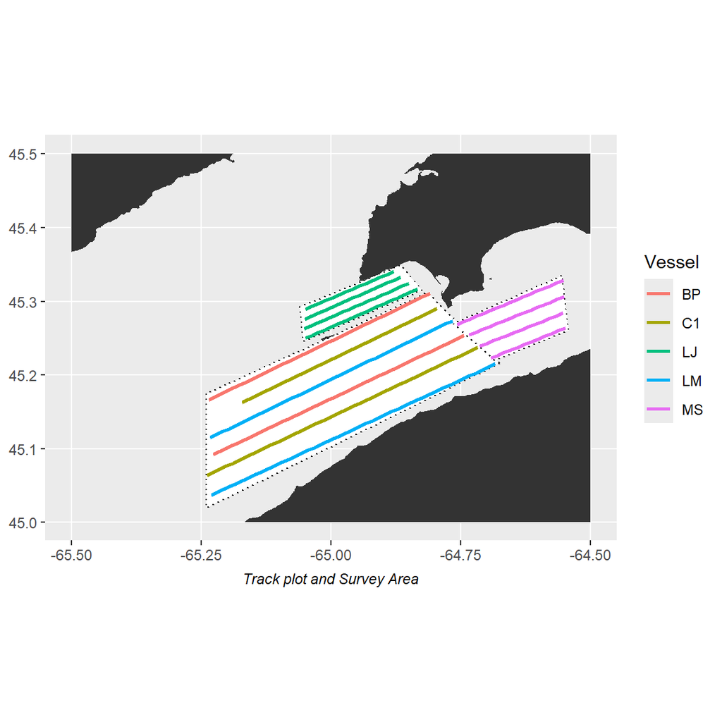

There was no plankton tow or CTD cast conducted.

No tags were applied during this survey.

Samples were obtained for target strength estimation.

### Tides Tables

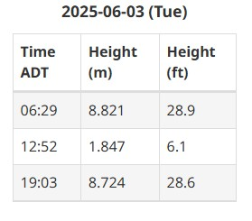

Tide Schedule for Margaretsville NS, Station #315m Source: www.waterlevels.gc.ca

### Acoustic Equipment

Each vessel was equipped with a Simrad ES38-18/200-18C combi (2-in-1) transducer prior to the survey that contains a 38kHz split beam and 200 kHz single beam transducer. Data was logged to the computer hard-drive for post-processing. All participating boats were calibrated on 38kHz before the survey.

## Survey Results

### Main Results

The results are subject to change as DFO will re-evaluate data editing, area estimation and apply a target strength.

**Preliminary biomass prediction for Scots Bay using standardized parallel transects is 123,037mt, and with turnover applied 109,821mt.**

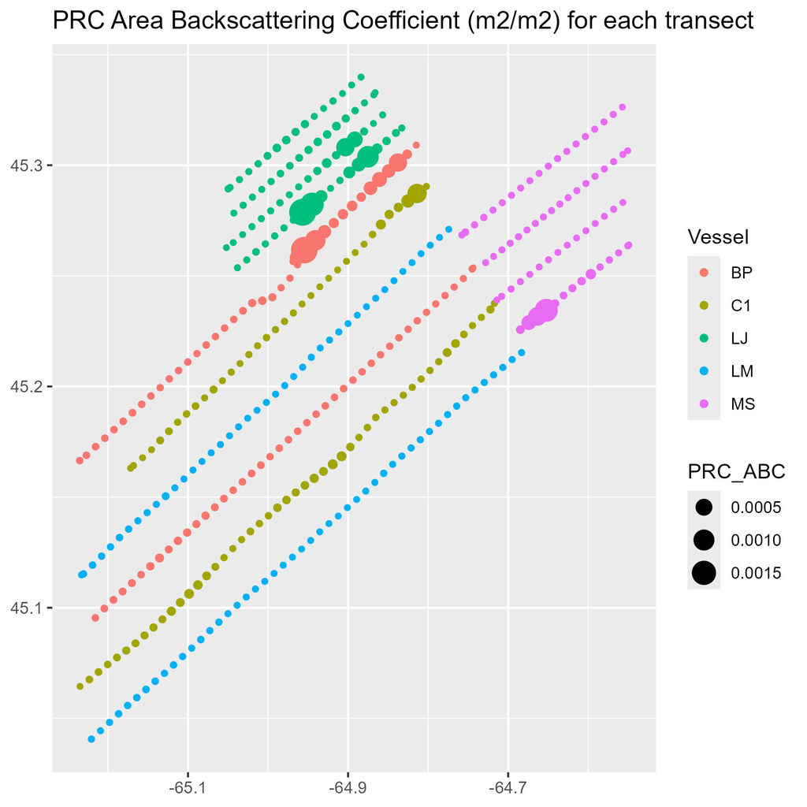

The Brunswick Provider stopped halfway down their second transect to fish, then returned to complete their line.This is noted within the Echoview editing.

### Transect Details

Table 1: Transect Details

| Vessel | Transect # | Date/Time Start | Date/Time End | Start Lon | Start Lat | End Lon | End Lat | Location | Distance (km) | Speed |
| --- | --- | --- | --- | --- | --- | --- | --- | --- | --- | --- |
| BP | T01 | 2025-06-03 19:43:59 | 2025-06-03 22:35:46 | -65.227 | 45.092 | -64.744 | 45.254 | SB | 42.04 | 7.93 |
| BP | T02 | 2025-06-03 23:02:18 | 2025-06-04 03:39:39 | -64.809 | 45.311 | -65.235 | 45.166 | SB | 41.24 | 4.82 |
| C1 | T01 | 2025-06-03 19:39:59 | 2025-06-03 22:46:56 | -65.238 | 45.064 | -64.717 | 45.238 | SB | 46.83 | 8.12 |
| C1 | T02 | 2025-06-03 23:11:16 | 2025-06-04 01:21:50 | -64.796 | 45.291 | -65.172 | 45.163 | SB | 33.85 | 8.40 |
| LJ | T01 | 2025-06-03 19:41:56 | 2025-06-03 20:55:40 | -65.049 | 45.250 | -64.833 | 45.317 | SB | 18.59 | 8.17 |
| LJ | T02 | 2025-06-03 21:02:12 | 2025-06-03 22:07:42 | -64.851 | 45.324 | -65.052 | 45.263 | SB | 17.26 | 8.54 |
| LJ | T03 | 2025-06-03 22:13:58 | 2025-06-03 23:16:24 | -65.051 | 45.276 | -64.866 | 45.333 | SB | 15.93 | 8.27 |
| LJ | T04 | 2025-06-03 23:21:18 | 2025-06-04 00:13:50 | -64.880 | 45.340 | -65.050 | 45.289 | SB | 14.54 | 8.96 |
| LM | T01 | 2025-06-03 19:30:57 | 2025-06-03 22:46:00 | -65.231 | 45.037 | -64.683 | 45.215 | SB | 47.91 | 7.96 |
| LM | T02 | 2025-06-03 23:12:19 | 2025-06-04 01:45:54 | -64.766 | 45.274 | -65.233 | 45.115 | SB | 40.89 | 8.63 |
| MS | T01 | 2025-06-03 21:34:11 | 2025-06-03 22:32:30 | -64.692 | 45.223 | -64.549 | 45.264 | SB | 12.88 | 7.15 |
| MS | T02 | 2025-06-03 22:42:19 | 2025-06-03 23:28:24 | -64.553 | 45.284 | -64.714 | 45.239 | SB | 13.80 | 9.70 |
| MS | T03 | 2025-06-03 23:39:43 | 2025-06-04 01:01:39 | -64.734 | 45.255 | -64.551 | 45.307 | SB | 17.13 | 6.77 |
| MS | T04 | 2025-06-04 01:12:11 | 2025-06-04 02:19:39 | -64.552 | 45.329 | -64.758 | 45.268 | SB | 17.90 | 8.59 |

### Survey Summary

Table 2: Acoustic Survey Results

| Vessel | Transect No. | Target Strength (db/kg) | Mean Sa (/m2) | Biomass Density (kg/m2) |
| --- | --- | --- | --- | --- |
| LJ | T01 | -35.5 | -35.413 | 1.020 |
| MS | T01 | -35.5 | -36.855 | 0.732 |
| BP | T02 | -35.5 | -38.263 | 0.529 |
| LJ | T02 | -35.5 | -41.832 | 0.233 |
| C1 | T02 | -35.5 | -44.628 | 0.122 |
| C1 | T01 | -35.5 | -49.228 | 0.042 |
| LJ | T03 | -35.5 | -51.861 | 0.023 |
| LJ | T04 | -35.5 | -52.530 | 0.020 |
| BP | T01 | -35.5 | -52.784 | 0.019 |
| LM | T01 | -35.5 | -58.965 | 0.005 |
| MS | T04 | -35.5 | -59.579 | 0.004 |
| LM | T02 | -35.5 | -59.948 | 0.004 |
| MS | T03 | -35.5 | -61.627 | 0.002 |
| MS | T02 | -35.5 | -62.596 | 0.002 |

Note:  
Transects are listed from greatest to least backscatter.

Table 3: Survey Summary Table

| Layer | Target Strength | Area (km2) | Mean Sa | Density (kg/m2) | Biomass (tons) | Percent Area | Percent Biomass | Standard Error (tons) | Standard Error (%) |
| --- | --- | --- | --- | --- | --- | --- | --- | --- | --- |
| Main Box | -35.5 | 641.81040 | -44.8888 | 0.1201 | 73,879.91 | 75.9 | 60.0 | 53,784.58 | 72.80 |
| Northern Box | -35.5 | 87.27066 | -39.9796 | 0.3239 | 31,110.35 | 10.3 | 25.3 | 20,714.11 | 66.58 |
| Eastern Box | -35.5 | 116.42950 | -43.5966 | 0.1851 | 18,046.86 | 13.8 | 14.7 | 21,225.76 | 117.61 |

### Greatest Biomass Densities

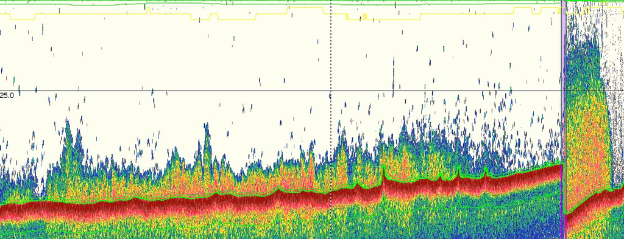

A snip from the transect with the greatest biomass density (kg/m2)

The single point with the largest biomass density (kg/m2) was recorded by **LJ**, at the following location:

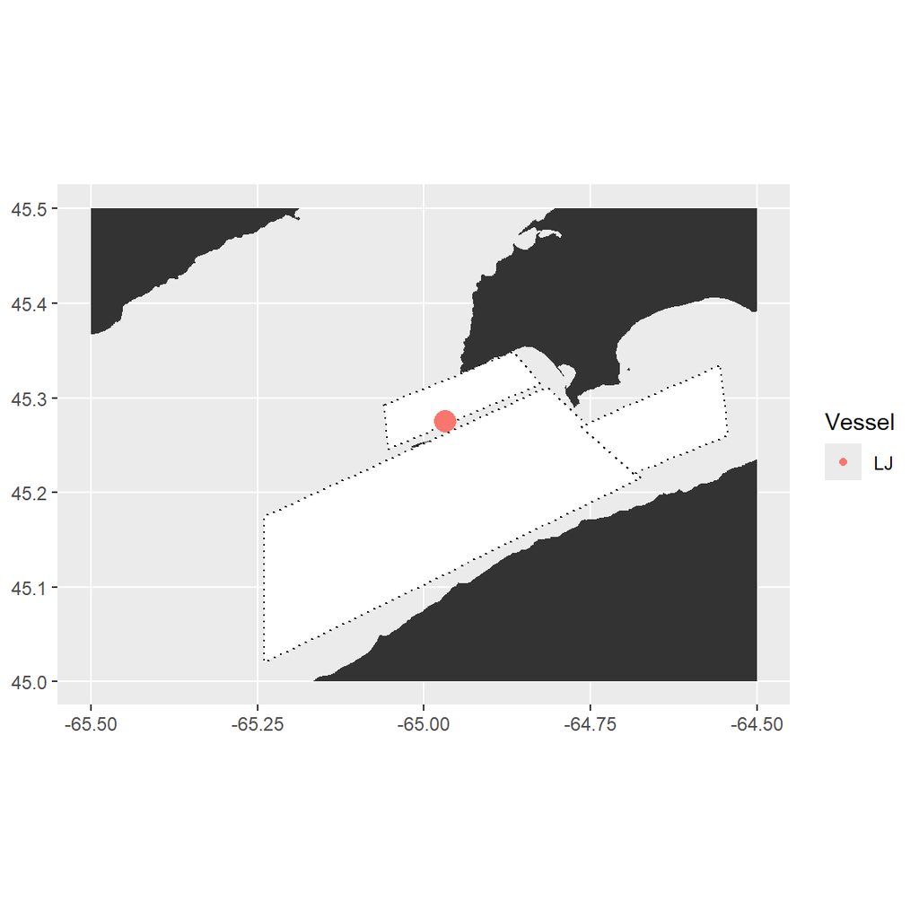

The transect with the greatest average biomass density (kg/m2) was recorded by **LJ**, at the following location:

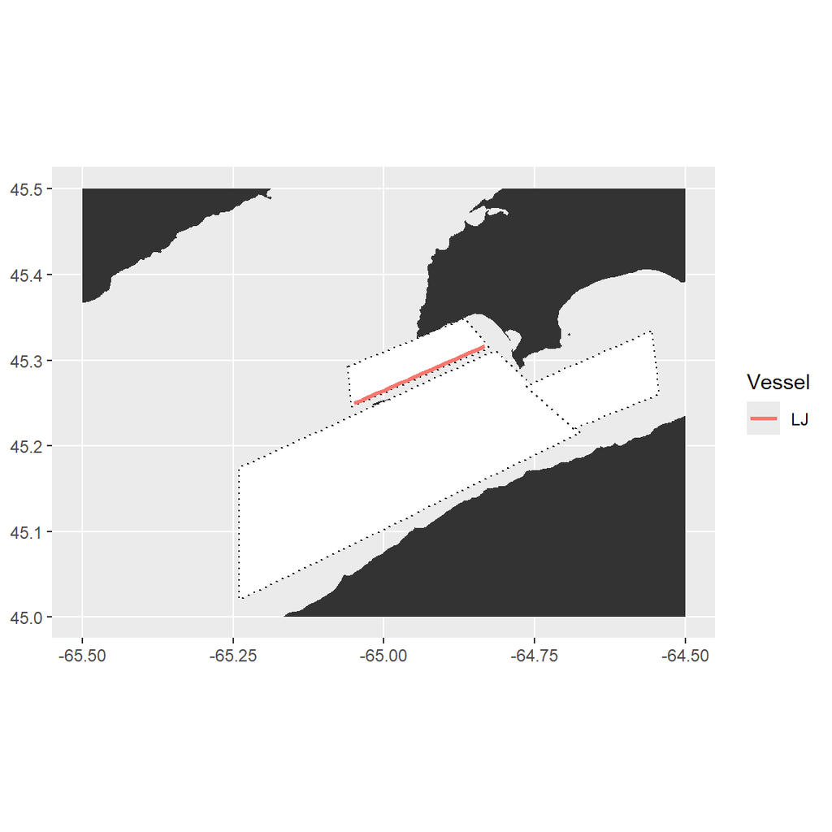

### Annual Summaries

This table does not include the biomass from adhoc surveys.

Table 4: Annual Comparison Table

| Ground | Survey Number | Current Year Survey Date | Current Year HSC Estimate | Current Year HSC Turnover Adjusted | Previous Year Survey Date | Previous Year HSC Estimate | Previous Year HSC Turnover Adjusted | Previous Year DFO Estimate | Previous Year DFO Turnover Adjusted |
| --- | --- | --- | --- | --- | --- | --- | --- | --- | --- |
| Scots Bay | 1 | 2025-05-06 | 12,306 | NA | 2024-05-05 | 78,662 | 78,662 | NA | NA |
| Scots Bay | 2 | 2025-05-21 | 120,045 | 118,023 | 2024-05-20 | 29,842 | 17,255 | NA | NA |
| Scots Bay | 3 | 2025-06-03 | 123,037 | 109,821 | 2024-06-02 | 93,804 | 89,523 | NA | NA |
| Scots Bay | 4 | NA | NA | NA | 2024-06-16 | 33,347 | 22,278 | NA | NA |
| Scots Bay | 5 | NA | NA | NA | 2024-07-01 | 7,252 | 3,123 | NA | NA |
| Scots Bay | 6 | NA | NA | NA | 2024-07-15 | 4,539 | 3,560 | NA | NA |
| Scots Bay | 7 | NA | NA | NA | 2024-07-29 | 32,655 | 32,016 | NA | NA |
| Scots Bay | 8 | NA | NA | NA | 2024-08-11 | 15,213 | 10,296 | NA | NA |
| Scots Bay | 9 | NA | NA | NA | 2024-08-25 | 9,206 | 6,810 | NA | NA |
| Scots Bay | 10 | NA | NA | NA | 2024-09-08 | 13,418 | 12,121 | NA | NA |
| Scots Bay | 11 | NA | NA | NA | 2024-09-23 | 8,735 | 7,098 | NA | NA |

Table 5: Annual Summary Table

| Year | Ground | HSC Estimate | HSC Turnover Adjusted | DFO Estimate | DFO Turnover Adjusted |
| --- | --- | --- | --- | --- | --- |
| 2024 | Scots Bay | 326,673 | 282,742 | NA | NA |
| 2025 | Scots Bay | 255,388 | 227,844 | NA | NA |

## Tagging, Plankton, and CTD Data

### Summary map

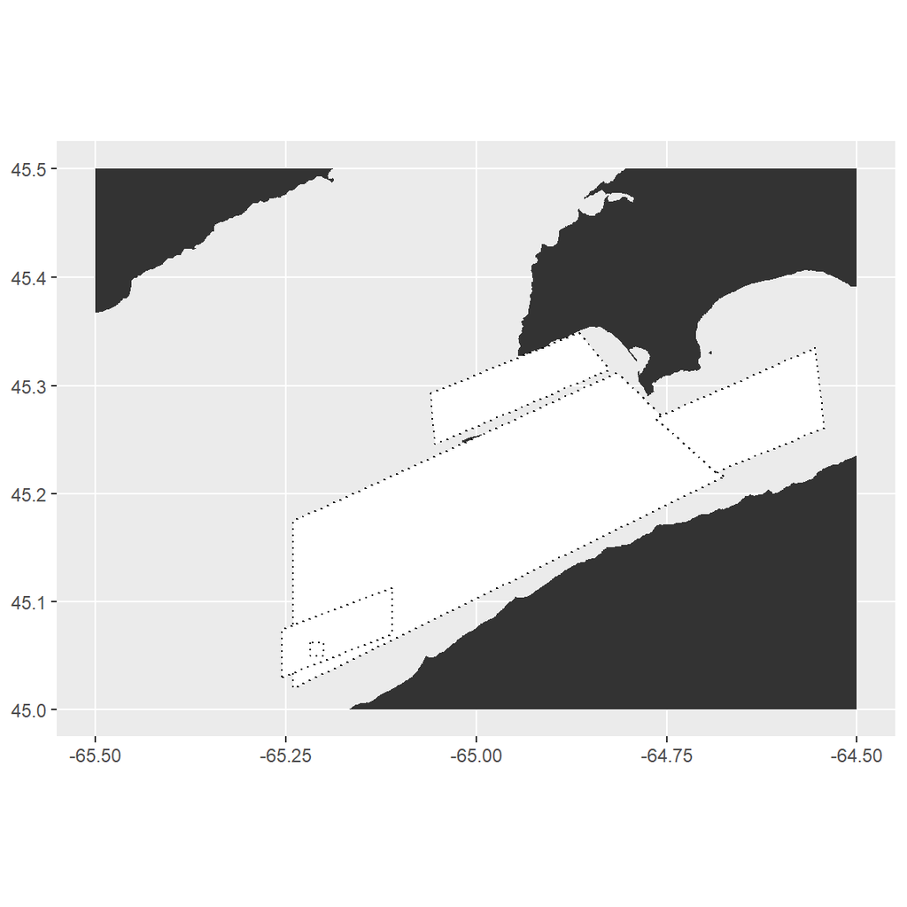

| Vessel | Tags |
| --- | --- |

### Plankton Data

#### Tow Summary Table

|  | Tow 1 | Tow 2 |
| --- | --- | --- |
| **Base Details** |  |  |
| Vessel | NA | NA |
| Set Number | NA | NA |
| Ground | SB | SB |
| Date | 03/06/2025 | 03/06/2025 |
| Wind Direction (km/h) | NA | NA |
| Swell (m) | NA | NA |
| Air Temp (c) | NA | NA |
| **Tow Details** |  |  |
| Tow Start | NA | NA |
| Tow End | NA | NA |
| Start Lat | NA | NA |
| End Lat | NA | NA |
| Start Lon | NA | NA |
| End Lon | NA | NA |
| Avg Tow Depth (m) | NA | NA |
| Speed | NA | NA |
| Heading | NA | NA |
| Tide Direction | NA | NA |
| **Other Data Collection** |  |  |
| Flow Start | NA | NA |
| Flow End | NA | NA |
| No. Revolutions | NA | NA |
| Distance (m) | NA | NA |
| Volume | NA | NA |
| Secchi Disappear (m) | NA | NA |
| Secchi Reappear (m) | NA | NA |